# Statistics 744, McMaster University

# coefficient plots, etc.

# setup

## load packages

```
library(tidyverse)
## graphics
theme_set(theme_bw()+theme(panel.spacing=grid::unit(0,"lines")))
## modeling/coef plots
library(lme4)
library(broom)
library(broom.mixed)
library(dotwhisker)
library(stargazer) ## coef tables
## predictions/effects plots
library(emmeans)
library(effects)
library(ggeffects)
## also: margins, marginaleffects, sjPlot, ...
library(remef) ## remotes::install_github("hohenstein/remef")
library(faux)
```

# coefficient plots

## principles

- make it easy to compare magnitudes
- use appropriate scales
- which comparisons do you want to make?
- typically drop intercept (why?)

## nuts and bolts

- old and busted: `arm::coefplot`, `coefplot2`
- new hotness:
  - `broom[.mixed]` + `ggplot2`
  - `dotwhisker`

## example

```
data(Contraception,package="mlmRev")
Contraception <- Contraception %>%
    mutate(ch = factor(livch != 0, labels = c("N", "Y")))
m3 <- glmer(use ~ age * ch + I(age^2) + urban + (1 | urban:district),
            data=Contraception, family=binomial)
```

## coefficient table

```
stargazer(m3,type="html")
```

|  | *Dependent variable:* |
| --- | --- |
|  | use |
| age | -0.046** |
|  | (0.022) |
| chY | 1.213*** |
|  | (0.210) |
| I(age2) | -0.006*** |
|  | (0.001) |
| urbanY | 0.787*** |
|  | (0.172) |
| age:chY | 0.066*** |
|  | (0.026) |
| Constant | -1.341*** |
|  | (0.222) |
| Observations | 1,934 |
| Log Likelihood | -1,177.237 |
| Akaike Inf. Crit. | 2,368.475 |
| Bayesian Inf. Crit. | 2,407.446 |
| *Note:* | p<0.1; p<0.05; p<0.01 |

**Also see** `broom`/`broom.mixed` + `huxtable` packages

## coefficient plot

```
gg0 <- dotwhisker::dwplot(m3, by_2sd=TRUE)
print(gg0)
```

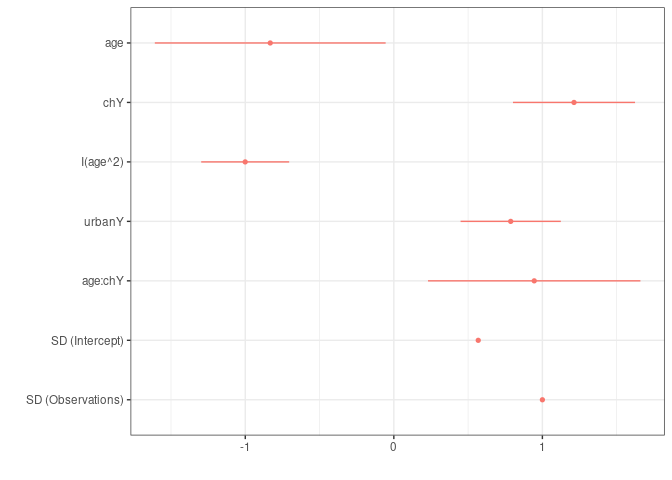

## add reference line

```
gg1 <- gg0 + geom_vline(xintercept=0,lty=2)
print(gg1)
```

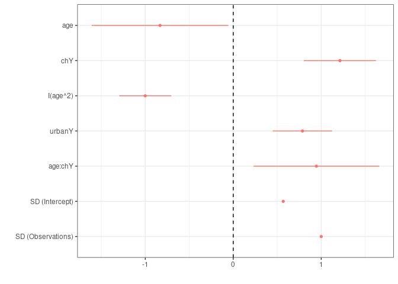

## scaling

- need to scale parameters appropriately to compare magnitude
- Gelman (2008); Schielzeth (2010)
- `arm::standardize`, `arm::rescale` (handy but inefficient)

> binary.inputs: options for standardizing binary variables, default is ‘center’; ‘0/1’ keeps original scale; ‘-0.5,0.5’ rescales 0 as -0.5 and 1 as 0.5; ‘center’ subtracts the mean; and ‘full’ subtracts the mean and divides by 2 sd.
- mixed models: standard deviations have same scale as corresponding parameter

## dwplot without auto-scaling

Look at results if we turn *off* auto-scaling (default)

```
dotwhisker::dwplot(m3, by_2sd = FALSE)
```

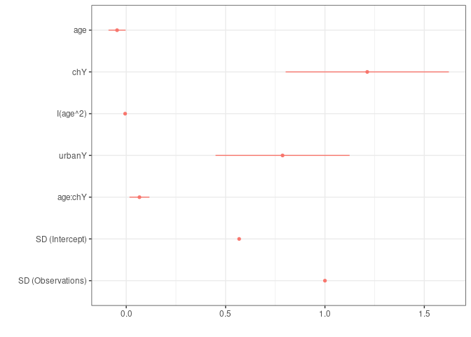

## alternative: explicitly scale age parameter

```
Contraception <- Contraception %>%
    mutate(sc_age = drop(scale(age)))
m3_sc <- update(m3,
      . ~ sc_age * ch + I(sc_age^2) + urban + (1 | urban:district))
```

## plot

```
dotwhisker::dwplot(m3_sc, effects="fixed", by_2sd = FALSE) +
    geom_vline(xintercept=0,lty=2)
```

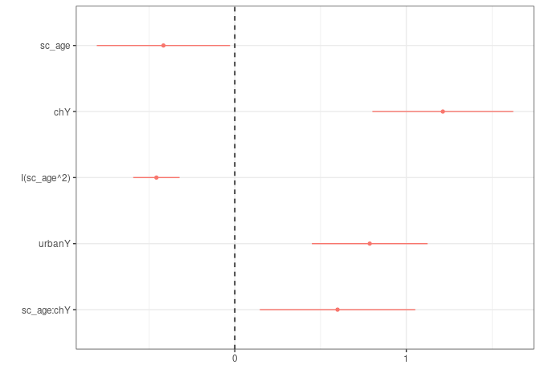

## other alternatives

- scaling makes units harder to interpret
- separate sets of predictors into facets according to their units
- ??

## manually tidying

```
cc <- broom.mixed::tidy(m3_sc,effects="fixed")
print(cc,digits=3)

## # A tibble: 6 × 6
##   effect term        estimate std.error statistic  p.value
##   <chr>  <chr>          <dbl>     <dbl>     <dbl>    <dbl>
## 1 fixed  (Intercept)   -1.34     0.222      -6.04 1.56e- 9
## 2 fixed  sc_age        -0.416    0.198      -2.10 3.57e- 2
## 3 fixed  chY            1.21     0.210       5.79 7.18e- 9
## 4 fixed  I(sc_age^2)   -0.457    0.0690     -6.62 3.51e-11
## 5 fixed  urbanY         0.787    0.172       4.57 4.88e- 6
## 6 fixed  sc_age:chY     0.599    0.231       2.59 9.57e- 3
```

## GLM for comparison

```
m3_fixed <-  glm(
    use ~ sc_age * ch + I(sc_age^2) + urban,
    data=Contraception, family=binomial)
dotwhisker::dwplot(list(sc_GLMM=m3_sc, GLM=m3_fixed))+
    geom_vline(xintercept=0,lty=2)+ scale_colour_brewer(palette="Dark2")
```

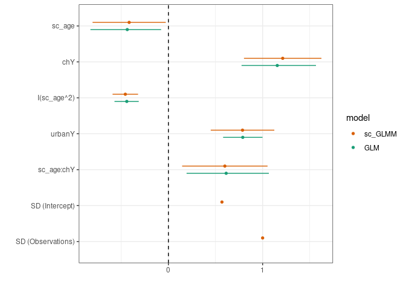

## dotwhisker limitations

- sometimes gets “confused” with complex models
- might want to post-process output of `tidy()` (edit variable/term names, etc.)
- use `purrr::map_dfr(list(mod1=, mod2=, .id = "model")` to process a list of models and collapse to a tibble

## alternative: data prep

```
m3_res <- (purrr::map_dfr(list(with_re = m3_sc, no_re=m3_fixed),
                  tidy,
                  conf.int = TRUE,
                  .id = "model")
  %>% mutate(term=fct_inorder(term))
  %>% filter(term!="(Intercept)")
)
```

(`purrr::map_dfr` == “run function on elements of a list, bind results into a single data frame, add `.id` column based on names of the list elements”)

## alternative: plot

```
pd <- position_dodge(width=0.5)
(gg5 <- ggplot(m3_res,aes(x=estimate,y=term,colour=model))
  + geom_pointrange(aes(xmin=conf.low,xmax=conf.high),
                    position=pd)
  + labs(y="")
  + scale_colour_brewer(palette="Dark2") + geom_vline(xintercept=0,lty=2))
```

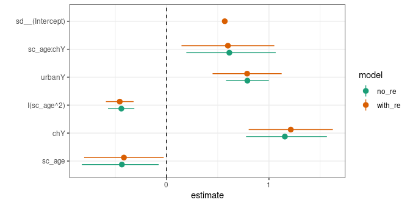

## reorder terms

```
m3_res_order <- mutate(m3_res,term=reorder(term,estimate))
gg5 %+% m3_res_order
```

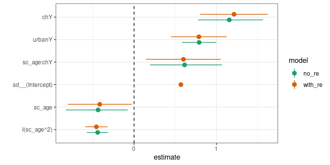

## caterpillar plots

- Useful when plotting *many* parallel/similar coefficients
- e.g.:
  - random effects in a mixed model
  - bioinformatics: genes, microbial species, etc..

## caterpillar plots (utility)

Reorders levels, allowing for multiple terms per level

```
caterpillar_levels <- function(x, order_term = "(Intercept)") {
    lev_order <- (x
        %>% filter(term==order_term)
        %>% group_by(level)
        %>% summarise(across(estimate, mean, na.rm = TRUE))
        %>% arrange(estimate)
        %>% pull(level)
    )
    x <- dplyr::mutate(x, across(level, factor, levels = lev_order))
    return(x)
}
```

## caterpillar plot

```
cat_data  <- (m3
  %>% broom.mixed::tidy(m3, effects="ran_vals")
  %>% select(level, term, estimate, std.error)
  %>% caterpillar_levels()
)
ggplot(cat_data, aes(level, estimate,
                     ymin = estimate-2*std.error,
                     ymax = estimate+2*std.error)) +
  geom_pointrange() +
  guides(x = guide_axis(n.dodge = 3))
```

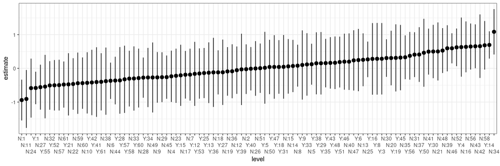

## summary

- useful in comparing lots of models;  
  models with many parallel parameters
- separate parameter types with facets
- sort by magnitude of estimate

## other thoughts

- can often use a wide aspect ratio (don’t need much height)
- may want to replace/improve coefficient names (`faux` package?)
- Bayesian models: violin plots of posterior samples? Or 50% + 95% intervals?

# marginal/effects/prediction plots

## emmeans

```
e1 <- emmeans(m3, ~age*ch, at=list(age=-14:20), type="response")
plot(e1)
```

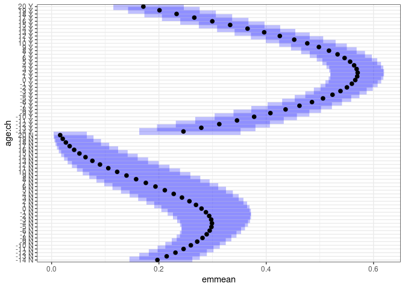

## as.data.frame → ggplot

```
e1d <- as.data.frame(e1)
print(gg1 <- ggplot(e1d,
              aes(age, prob, colour=ch, fill=ch,
                  ymin=asymp.LCL, ymax=asymp.UCL)) +
  geom_line() +
  geom_ribbon(colour=NA, alpha=0.2))
```

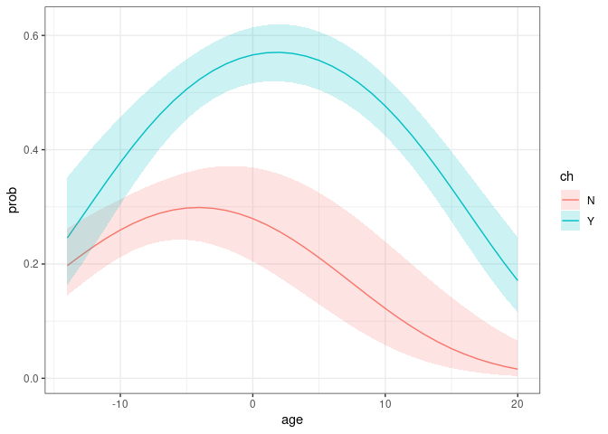

## effects

```
plot(ae <- allEffects(m3, xlevels = list(age=51)))
```

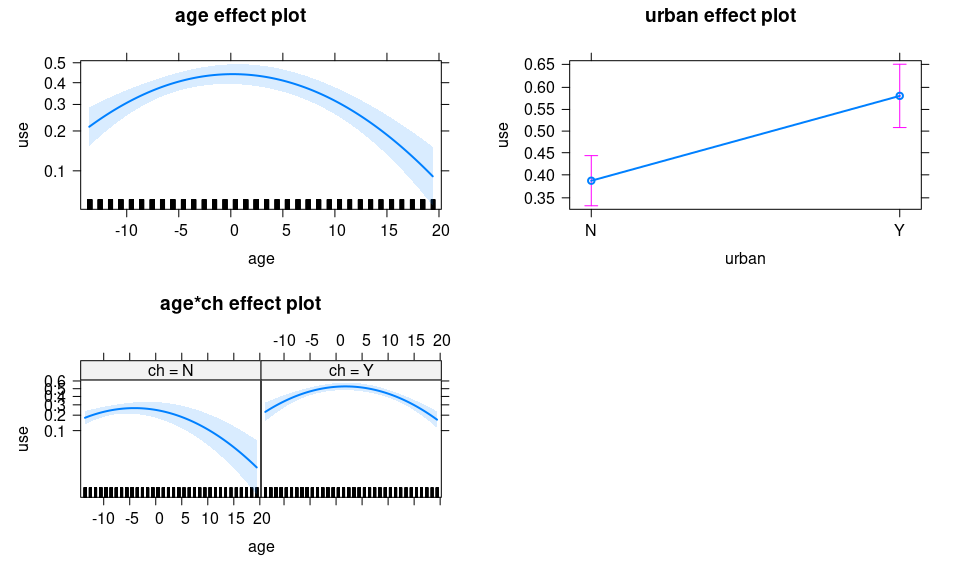

## as.data.frame

```
aed <- as.data.frame(ae)[["age:ch"]]
gg1 %+% aed + aes(y=fit, ymin=lower, ymax=upper)
```

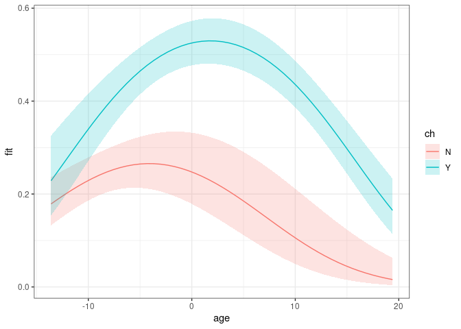

## ggeffects

```
ag <- ggeffect(m3, terms=c("age [all]", "ch"))
plot(ag)
```

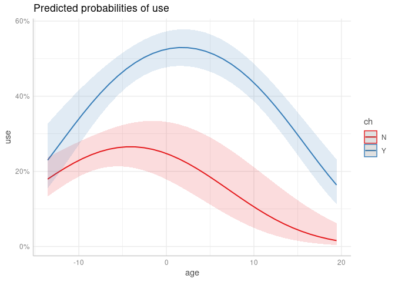

## partial effects removal

‘Correct’ data for non-focal terms:

$$\\beta\_0 + \\sum\_{i \\in \\substack{\\textrm{focal} \\\\ \\textrm{params}}} \\beta\_i x\_i + \\textrm{resid}\_i$$

or

$$Y\_i - \\sum\_{i \\in \\substack{\\textrm{non-focal} \\\\ \\textrm{params}}} \\beta\_i x\_i$$

## example

```
fm1 <- lmer(Reaction ~ 1 + Days + (1 + Days | Subject), sleepstudy)
ag <- ggeffect(fm1, terms="Days [all]")
gg2 <- plot(ag) + geom_point(data=sleepstudy,
                             aes(x=Days, y = Reaction, colour=Subject)) +
  colorspace::scale_colour_discrete_qualitative(guide="none")
```

## example

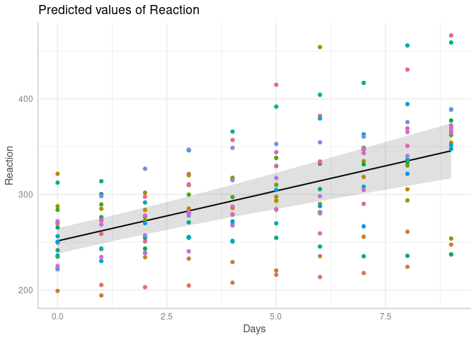

## example (cont.)

```
sleepstudy$re <- remef(fm1, ran = list(Subject = "Days"))
gg3 <- plot(ag) + geom_point(data=sleepstudy,
                      aes(x=Days, y = re, colour=Subject)) +
  colorspace::scale_colour_discrete_qualitative(guide="none")
cowplot::plot_grid(gg2, gg3)
```

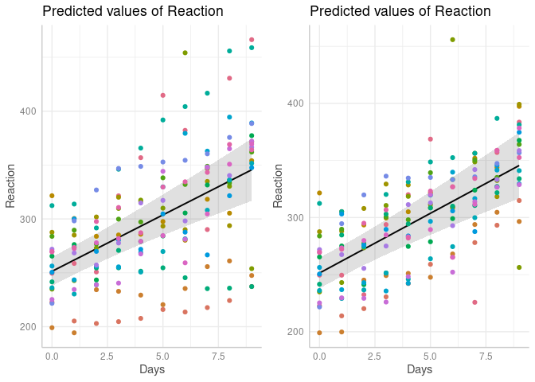

## faux: nice contrast names

```
mm <- (mtcars
  %>% mutate(across(cyl, contr_code_treatment))
)
m1 <- lm(mpg ~ disp*cyl, mm)
dwplot(m1, by_2sd=TRUE) + geom_vline(xintercept = 0, lty=2)
```

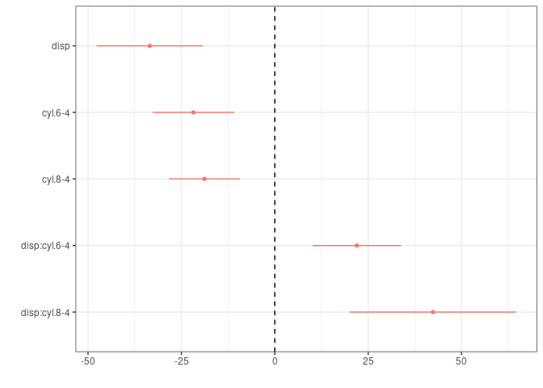

## references

Gelman, Andrew. 2008. “Scaling Regression Inputs by Dividing by Two Standard Deviations.” *Statistics in Medicine* 27 (15): 2865–73. https://doi.org/10.1002/sim.3107.

Schielzeth, Holger. 2010. “Simple Means to Improve the Interpretability of Regression Coefficients.” *Methods in Ecology and Evolution* 1: 103–13. https://doi.org/10.1111/j.2041-210X.2010.00012.x.

Course home page